# Equipo 1

## Pregunta 1

Observando los datos, la memorista sospecha que hay diferencias significativas en el tiempo de ejecución entre las versiones A y B del algoritmo cuando las instancias tienen 70 o más nodos. ¿Los datos respaldan la intuición de la memorista? Para responder, filtren los datos para tener las instancias con 70 o más nodos y seleccionen las columnas de los tiempos de ejecución de las versiones A y B (en formato ancho). Usando como semilla el valor 73, obtengan muestras aleatorias independientes de 24 tiempos registrados por la versión A y 20 tiempos registrados por la versión B del algoritmo. Realicen un análisis estadístico pertinente (enunciar hipótesis, revisar condiciones, seleccionar pruebas ómnibus y post-hoc según corresponda) para responder la pregunta planteada, utilizando pruebas no paramétricas de ser necesario.

```r
set.seed(73)
datos <- read.csv("EP07 Datos.csv")
datos1 <- datos %>% filter(n.nodos >= 70)

datos1A <- sample(datos$tiempo.A,24)
datos1B <- sample(datos$tiempo.B,20)

# Se iguala la longitud rellenando con NA
max_len <- max(length(datos1A), length(datos1B))
datos1A_tab <- c(datos1A, rep(NA, max_len - length(datos1A)))
datos1B_tab <- c(datos1B, rep(NA, max_len - length(datos1B)))

# Crear tabla de anchura
tabla_ancha <- data.frame(tiempo.A = datos1A_tab, tiempo.B = datos1B_tab)

print(tabla_ancha)
```

```
##    tiempo.A tiempo.B
## 1    726535  3380926
## 2    589858   448861
## 3   1205085  1989766
## 4   1235364   947924
## 5   4028596  1064593
## 6    313221  3025824
## 7    125645   599805
## 8     82760  2970598
## 9   1059855  1067112
## 10   257457  3595410
## 11   205476   719512
## 12   113916   901646
## 13   282347  1791186
## 14   730137  2704848
## 15  2928374  1369662
## 16  1036198  1479578
## 17  2740821  2971608
## 18   154137  1850743
## 19  1756578   508673
## 20  2521193  1911543
## 21   478989       NA
## 22   221955       NA
## 23  2423249       NA
## 24   761288       NA
```

Para la creación de la tabla de anchura, dado que los datos de A y B tienen tamaños distintos rellenamos con NA hasta que tengan la misma longitud. Con la tabla realizada procedemos a comprobar las condiciones para poder utilizar la prueba t de dos muestras:

1.- Las observaciones elegidas son independientes entre sí. 2.- Las observaciones de las dos muestras provienen de una población con distribución cercana a la normal. 3.- Las muestras son independientes entre sí.

La condición 1 y 3 se cumplen, ya que los datos provienen de ejecuciones independientes de dos versiones diferentes del algoritmo. Para verificar la condición 2 (normalidad), se aplican pruebas de Shapiro-Wilk a cada muestra:

```r
norm_datosA <- shapiro.test(datos1A)

print(norm_datosA)
```

```
##
##  Shapiro-Wilk normality test
##
## data:  datos1A
## W = 0.82995, p-value = 0.0009489
```

```r
norm_datosB <- shapiro.test(datos1B)

print(norm_datosB)
```

```
##
##  Shapiro-Wilk normality test
##
## data:  datos1B
## W = 0.91822, p-value = 0.09159
```

Los resultados indican que los datos del algoritmo A no siguen una distribución normal (p = 0.00095 < 0.05), mientras que los datos del algoritmo B podrían considerarse normales (p = 0.0915 > 0.05), aunque no de forma muy evidente. Dado que la condición de normalidad no se cumple en ambos grupos, no es apropiado aplicar una prueba t, por lo que se recurre a una prueba no paramétrica.

Se evalúan las condiciones necesarias para aplicar la prueba de suma de rangos de Wilcoxon:

1.- Las observaciones de ambas muestras son independientes. 2.- La escala de medición empleada debe ser a lo menos ordinal.

Ambas condiciones se satisfacen, por lo tanto, se procede con esta prueba. Las hipótesis son:

$H_0$: No existe diferencia en los tiempos de ejecución entre los algoritmos A y B.

$H_a$: Existe una diferencia en los tiempos de ejecución entre los algoritmos A y B.

```r
alfa <- 0.05

# Hacer y mostrar la prueba de suma de rangos de Wilcoxon (Mann-Whitney)
prueba <- wilcox.test(tabla_ancha$tiempo.A, tabla_ancha$tiempo.B,
                      alternative = "two.sided",
                      conf.level = 1 - alfa)

# Mostrar resultados
print(prueba)
```

```
##
##  Wilcoxon rank sum exact test
##
## data:  tabla_ancha$tiempo.A and tabla_ancha$tiempo.B
## W = 131, p-value = 0.009544
## alternative hypothesis: true location shift is not equal to 0
```

## Pregunta 2

La memorista también sospecha que, al comparar las mismas instancias de prueba con iguales características, las mejores soluciones encontradas por las versiones B y C tienen rendimientos distintos. ¿Estará en lo cierto? Para responder, filtren los datos para tener las instancias con 70 o más nodos y seleccionen las columnas con el mejor rendimiento de las versiones B y C en formato ancho. Usando como semilla el valor 71, obtengan una muestra aleatoria de 24 instancias. Realicen un análisis estadístico pertinente (enunciar hipótesis, revisar condiciones, seleccionar pruebas ómnibus y post-hoc según corresponda) para responder la pregunta planteada, utilizando pruebas no paramétricas de ser necesario.

```r
set.seed(71)

# Los indices para obtener el resultado de ambas ejecuciones
sampled_indices <- sample(nrow(datos1), 24)


datos2C <- datos1$mejor.C[sampled_indices]
datos2B <- datos1$mejor.B[sampled_indices]

DatosC <- c(datos2C)
DatosB <- c(datos2B)

frame <- data.frame(mejor.B = DatosB,mejor.C = DatosC)

print(frame)
```

```
##    mejor.B mejor.C
## 1    95.00   98.21
## 2    95.60   98.48
## 3    98.36   98.26
## 4    94.60   96.63
## 5    88.75   90.74
## 6    97.38   97.43
## 7    88.46   97.49
## 8    92.36   95.19
## 9    97.57   97.93
## 10   97.15   96.14
## 11   98.84   98.42
## 12   91.48   91.47
## 13   85.99   95.33
## 14   96.93   97.35
## 15   95.59   95.42
## 16   94.93   97.12
## 17   94.17   95.88
## 18   96.90   99.44
## 19   95.10   97.13
## 20   95.33   95.48
## 21   93.13   97.03
## 22   97.46   98.62
## 23   97.92   97.36
## 24   95.97   95.91
```

Con los datos ya extraídos procedemos al analisis del contexto y lo pedido, en este caso la memorista declara que si existe una diferencia el rendimiento de los mejores resultado de B y C. Para esto se nos pidio extraer aquellas muestras con 70 nodos o mas. Podemos tentativamente decir que podriamos utilizar un t-test o ANOVA para revisar si las media o proporciones de los resultados en ambas muestras son verdaderamente diferentes o iguales, por lo que para ello se necesitan revisar condiciones.

Para descartar mas rapido las opciones, primero se revisa la normalidad de los datos de los mejores resultados de B y C donde la cantidad de nodos se de 70 o mas.

```r
print(shapiro.test(datos1$mejor.C))
```

```
##
##  Shapiro-Wilk normality test
##
## data:  datos1$mejor.C
## W = 0.93625, p-value = 1.147e-05
```

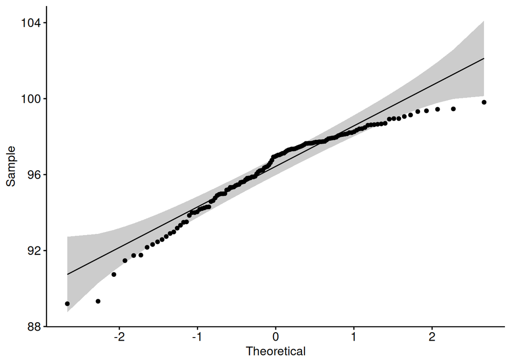

```r
qq2C <- ggqqplot(datos1$mejor.C)
print(qq2C)
```

```r
print(shapiro.test(datos1$mejor.B))
```

```
##
##  Shapiro-Wilk normality test
##
## data:  datos1$mejor.B
## W = 0.9322, p-value = 6.138e-06
```

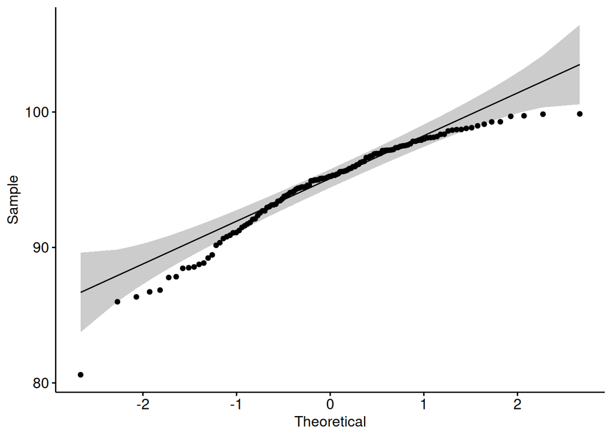

```r
qq2B <- ggqqplot(datos1$mejor.B)
print(qq2B)
```

Por lo visto, las muestras no siguen una disribución normal, por lo que test como t-test y ANOVA no son capaces de ser utilizados. En este caso podemos utilizar otro test conocido como el test Wilcoxon-Mann-Whiteney, el cual no necesita que los datos sigan una distribución normal, solo necesita que:

- Las muestras sean independientes unas de otras
- La escala de medición debe ser a lo menos ordinal, de modo que tenga sentido hablar sobre diferencias como “mayor”, “menor” o “igual

Por lo que se establecen las hipotesis y el nivel de confianza:

$H_0 :$ No existe diferencia significativa entre los mejores resultados del algoritmo B y C.

$H_a :$ Existe diferencia significativa entre los mejores resultados del algoritmo B y C

Estas pruebas seran ejecutadas con un nivel de confianza del 95%.

```r
testWilcox <- wilcox.test(frame$mejor.B, frame$mejor.C,alternative = "two.sided", paired = FALSE)
print(testWilcox)
```

```
##
##  Wilcoxon rank sum test with continuity correction
##
## data:  frame$mejor.B and frame$mejor.C
## W = 180.5, p-value = 0.02736
## alternative hypothesis: true location shift is not equal to 0
```

Al realizar el test utilizando la alternative = “two.sided”, estamos revisando solo si existe diferencias entre rendimientos, y con un alfa de 0.05 y p-value de 0.02736, se rechaza la hipotesis nula en favor de la alternativa, y concluyemos que los resultados de C y B son distintos, coincidiendo con la memorista.

## Pregunta 3

3. La memorista además cree que hay diferencias significativas en el tiempo de ejecución entre las diferentes versiones del algoritmo cuando las instancias de prueba tienen 50 o más nodos. ¿Los datos respaldan la intuición de la memorista? Para responder, filtren los datos para tener las instancias con 50 o más nodos y seleccionen las columnas con los tiempos de ejecución registrados (en formato ancho). Usando como semilla el valor 31, obtengan muestras aleatorias independientes de 14, 12 y 13 tiempos registrados por las versiones A, B y C, respectivamente. Realicen un análisis estadístico pertinente (enunciar hipótesis, revisar condiciones, seleccionar pruebas ómnibus y post-hoc según corresponda) para responder la pregunta planteada, utilizando pruebas no paramétricas de ser necesario.

```r
datos <- read.csv("EP07 Datos.csv",stringsAsFactors = TRUE)

df_a <- data.frame(tiempo = datos$tiempo.A)
df_b <- data.frame(tiempo = datos$tiempo.B)
df_c <- data.frame(tiempo = datos$tiempo.C)
```

Verificamos si se cumplen las condiciones para realizar la prueba paramétrica ANOVA.

- Escala de intervalos iguales: la dependiente Tiempo se encuentra en milisegundos, donde la diferencia entre un valor 988 y 989, es la misma distancia que 981 y 982, es decir la diferencia es de 1 milisegundo constante entre todos los valores.
- La población sigue una distribución normal:

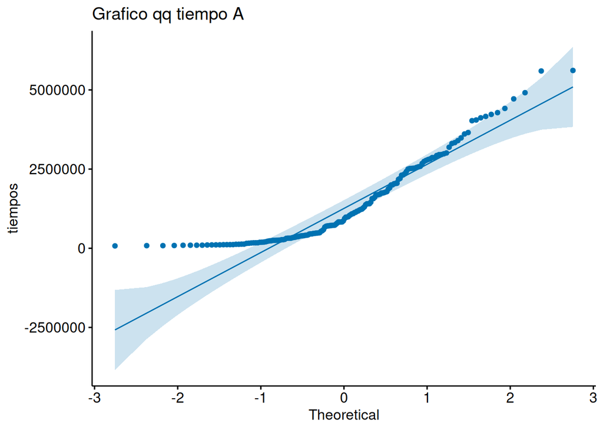

```r
gg_a = ggqqplot(data = df_a,x = "tiempo",main="Grafico qq tiempo A",ylab="tiempos", color = "#0072B2")

gg_b = ggqqplot(data = df_b,x = "tiempo",main="Grafico qq tiempo B",ylab="tiempos", color = "#D55E00")

gg_c = ggqqplot(data = df_c,x = "tiempo",main="Grafico qq tiempo C",ylab="tiempos", color = "#CC79A7")

print(gg_a)
```

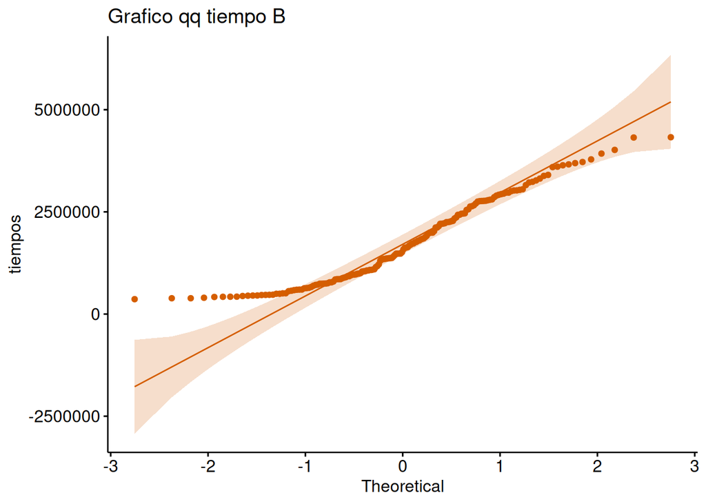

```r
print(gg_b)
```

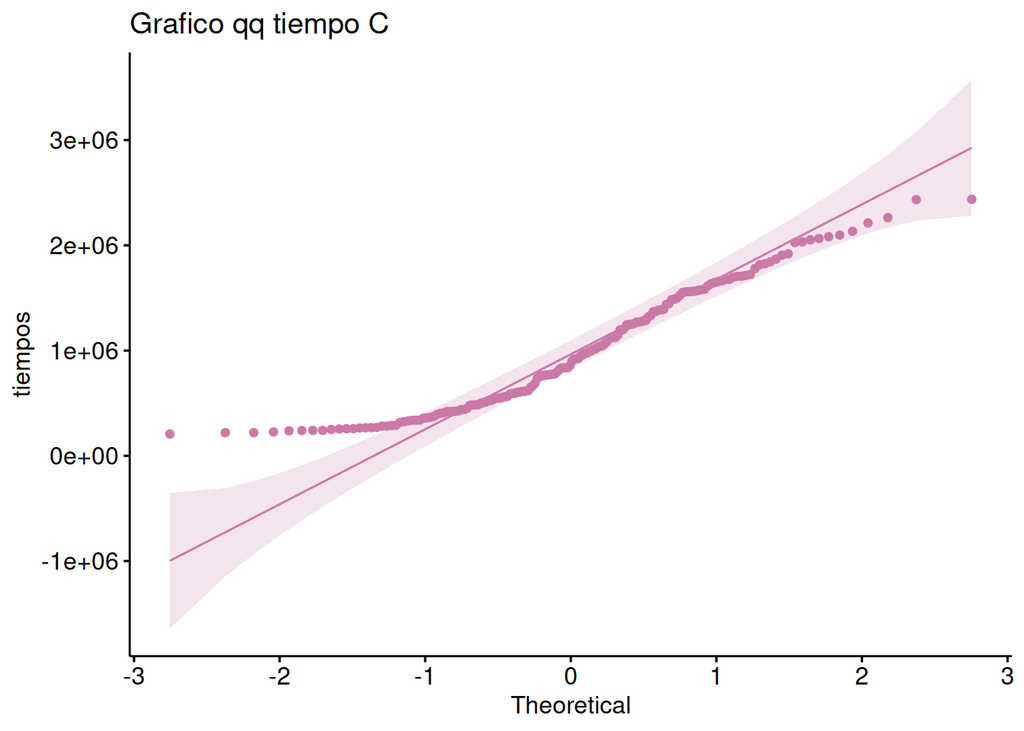

```r
print(gg_c)
```

Analizando los gráficos observamos que en las tres muestras existen puntos que se encuentran fuera del gráfico, por lo tanto estos no siguen una distribución normal.

Dado que no se cumple una condición, no es posible utilizar la prueba paramétrica ANOVA.

A continuación se verifican las condiciones necesarias para utilizar la prueba no paramétrica con más de dos muestras numéricas, en este caso, se tienen que las muestras son de tamaño diferente, por lo cual se empleará la prueba de Kruskal-Wallis.

- La escala de la variable dependiente debe ser, a lo menos, ordinal: la variable dependiente es el Tiempo de ejecución (en milisegundos), lo cual indica que es una variable numérica continua.
- Las observaciones son independientes entre sí: en el contexto de la pregunta se indica la utilización de muestras aleatorias independientes entre si de tamaño 14, 12 y 13.
- La variable independiente debe tener a lo menos dos niveles: en el contexto de la pregunta se indica que se debe considerar los tiempos de ejecución de los algoritmos A, B y C, por lo que se tienen 3 niveles.

Las tres condiciones de la prueba Kruskal-Wallis se cumplen satisfactoriamente, por consiguiente, procederemos a enunciar las hipótesis de la prueba:

$H_o:$ La distribución de los tiempos de ejecución son iguales entre las versiones A,B y C, en instancias con 50 o más nodos.

$H_a:$ Al menos una versión del algoritmo tiene una distribución distinta a las otras, en instancias con 50 o más nodos.

Para la prueba se utilizará un nivel de confianza $⍺= 0.05$.

```r
datos_filtrados <- datos[datos$n.nodos >= 50, ]

set.seed(31)
datos_a <- sample(datos_filtrados$tiempo.A, 14)
datos_b <- sample(datos_filtrados$tiempo.B, 12)
datos_c <- sample(datos_filtrados$tiempo.C, 13)
```

```r
tiempos <- c(datos_a, datos_b, datos_c)
criterio <- factor(c(rep("A",14), rep("B", 12), rep("C", 13)))

tiempos_muestra <- data.frame(tiempos,criterio)

kruskal.test(tiempos ~ criterio, data = tiempos_muestra)
```

```
##
##  Kruskal-Wallis rank sum test
##
## data:  tiempos by criterio
## Kruskal-Wallis chi-squared = 2.7011, df = 2, p-value = 0.2591
```

```r
pairwise.wilcox.test( tiempos , criterio , p.adjust.method = "BH" , paired = FALSE , exact = FALSE )
```

```
##
##  Pairwise comparisons using Wilcoxon rank sum test with continuity correction
##
## data:  tiempos and criterio
##
##   A    B
## B 0.26 -
## C 0.94 0.26
##
## P value adjustment method: BH
```

Luego de la realización de la prueba Kruskal-Wallis como ómnibus, el resultado arrojó un $p-valor = 0.2591$, dado que se utilizó un nivel de confianza de 0.05, tenemos que $p-valor > ⍺$, por lo tanto, no tenemos evidencia suficiente para rechazar la hipótesis nula $H_o$. A pesar de que la prueba nos indicó que no existen diferencias significativas entre los tiempos de ejecución de los distintos algoritmos (A, B y C), se ejecutó la prueba pos-hoc de Benkamini y Hochberg para corroborar los resultados anteriores. Sus resultados que los $p-valor$ ajustados de :A-B = 0.26, A-C = 0.94 y B-C = 0.26, lo cual ningún valor es menor al nivel de significancia ⍺, es decir, los resultados son consistentes con la prueba de Kruskall-Wallis.

En conclusión, los datos de las muestras analizadas no respaldan la intuición de la memorista de que existen diferencias significativas en los tiempos de ejecución entre los distintos algoritmos cuando se tienen instancias de pruebas con 50 o más nodos.

```r
datos <- read.csv("EP07 Datos.csv",stringsAsFactors = TRUE)

df_mejora <- data.frame(mejor = datos$mejor.A)
df_mejorb <- data.frame(mejor = datos$mejor.B)
df_mejorc <- data.frame(mejor = datos$mejor.C)
```

Verificamos si se cumplen las condiciones para realizar la prueba paramétrica ANOVA.

- Escala de intervalos iguales: la variable dependiente de la pregunta se encuentra en porcentaje, donde la diferencia entre un 90% y 91% es la misma distancia que se tiene con 80% y 81%, es decir la diferencia es de 1% constante entre todos los valores
- La población sigue una distribución normal:

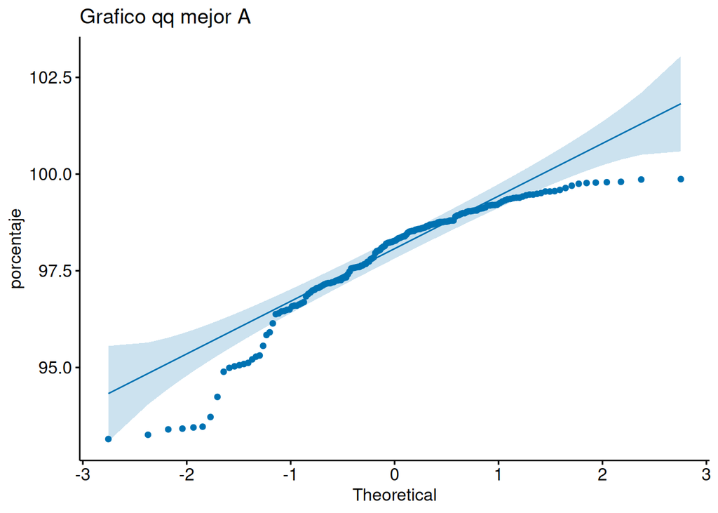

```r
gg_aa = ggqqplot(data = df_mejora,x = "mejor",main="Grafico qq mejor A",ylab="porcentaje", color = "#0072B2")

gg_bb = ggqqplot(data = df_mejorb,x = "mejor",main="Grafico qq mejor B",ylab="porcentaje", color = "#D55E00")

gg_cc = ggqqplot(data = df_mejorc,x = "mejor",main="Grafico qq mejor C",ylab="porcentaje", color = "#CC79A7")

print(gg_aa)
```

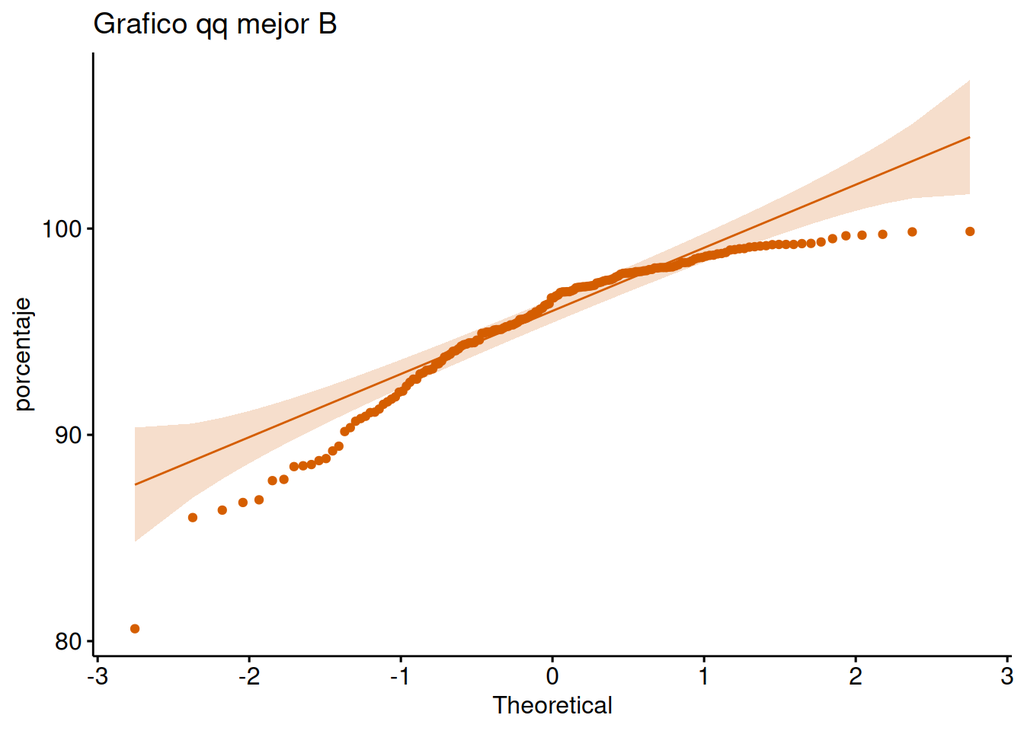

```r
print(gg_bb)
```

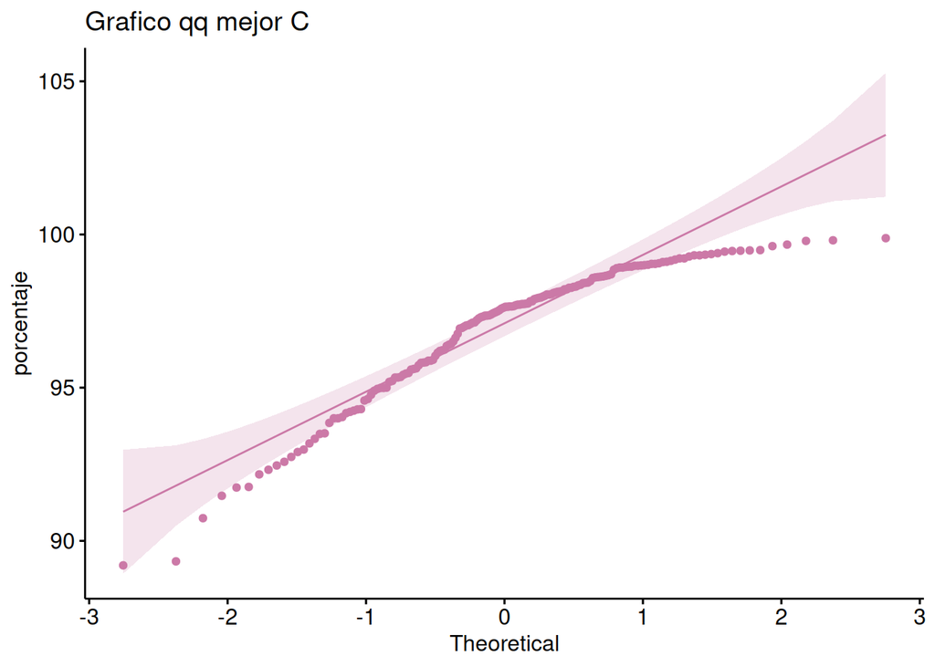

```r
print(gg_cc)
```

Analizando los gráficos observamos que en las tres muestras existen puntos que se encuentran fuera del gráfico, por lo tanto estos no siguen una distribución normal.

Dado que no se cumple una condición, no es posible utilizar la prueba paramétrica ANOVA.

A continuación se verifican las condiciones necesarias para utilizar la prueba no paramétrica con más de dos muestras numéricas, en este caso, se tienen que las muestras son de igual tamaño, por lo cual se empleará la prueba de Friedman.

- La escala de la variable dependiente debe ser, a lo menos, ordinal: la variable dependiente es el rendimiento (en porcentaje), lo cual indica que es una escala de razón, la cual tiene propiedades similares a las de una escala ordinal.
- Las observaciones son independientes entre sí: en el contexto de la pregunta se indica la utilización de muestras aleatorias independientes, entre los distintos tipos de algotirmos (A, B y C), con un tamaño de muestra de 22.
- La variable independiente debe ser categórica y tener al menos 3 niveles: en el contexto de la pregunta se indica que se debe considerar los mejores porcentajes de los algoritmos A, B y C, es de tipo categórica y posee 3 niveles.

Las tres condiciones de la prueba de Friedman se cumplen satisfactoriamente, por consiguiente, procederemos a enunciar las hipótesis de la prueba:

$H_o:$ no hay diferencia en los rendimientos entre los algoritmos A, B y C, es decir, que las medianas de los porcentajes son iguales para A, B y C.

$H_a:$ Al menos una versión del algoritmo tiene un rendimiento distinta a las otras, es decir, al menos una mediana de los algoritmos es diferente.

Para la prueba se utilizará un nivel de confianza $⍺= 0.01$ con tal de buscar una mayor rigurosidad de análisis.

```r
set.seed(31)
datos_filtrados <- datos[datos$n.nodos >= 50, ]

instancias_filtradas <- datos_filtrados[sample(nrow(datos_filtrados),22),]

datos_a <- instancias_filtradas$mejor.A
datos_b <- instancias_filtradas$mejor.B
datos_c <- instancias_filtradas$mejor.C

rendimientos <- c(datos_a, datos_b, datos_c)

criterio <- factor(c(rep("mejor A", 22), rep("mejor B",22), rep("mejor C", 22)))

instancia <- rep(1:22,3)

datos_finales <- data.frame(instancia, rendimientos, criterio)
alfa <- 0.01

friedman.test(rendimientos ~ criterio | instancia, data = datos_finales)
```

```
##
##  Friedman rank sum test
##
## data:  rendimientos and criterio and instancia
## Friedman chi-squared = 14.273, df = 2, p-value = 0.0007956
```

Luego de la realización de la prueba Friedman como ómnibus, el resultado arrojó un $p-valor = 0.0007956$, dado que se utilizó un nivel de confianza de 0.01, tenemos que $p-valor < ⍺$, esto nos indica que si existen diferencias de rendimientos entre las distintas versiones del algoritmo. por lo tanto, procede a rechazar la hipótesis nula en el contexto de la prueba de friedman. Dado este resultado, se procede a realizar una prueba post-hoc con el fin de comparar entre si los algoritmos e verificar los resultados y saber entre qué algoritmo existe diferencias de rendimientos.

```r
pairwise.wilcox.test(rendimientos, criterio, p.adjust.method = "holm", paired = TRUE, exact = FALSE)
```

```
##
##  Pairwise comparisons using Wilcoxon signed rank test with continuity correction
##
## data:  rendimientos and criterio
##
##         mejor A mejor B
## mejor B 0.0022  -
## mejor C 0.0461  0.1192
##
## P value adjustment method: holm
```

El resultado de la prueba post-hoc nos indica que existe una diferencia de rendimientos entre los algoritmos A-B con un $p-valor = 0.0022 < alfa = 0.01$, no así entre A-C y B-C.

En conclusión, los datos de las muestras analizadas respaldan el pensamiento de la memorista, ya que los resultados obtenidos en la prueba de Friedman y con al realizar un ajuste post-hoc, indican que existe una diferencia entre los rendimientos de los algoritmos A-B cuando se usa un nivel de significancia del 0.01.